# WHO Tuberculosis Data - Case Study

Emil Sievänen

1/14/2021

# Introduction

This notebook showcases basic data analysis process from data cleansing to data visualization and modelling. We will be using tuberculosis data acquired from the [World Health Organization](http://www.who.int/tb/country/data/download/en/), which is included in the `tidyr` package. The data cleansing process will follow the methodology introduced in the book [R for Data Science](https://r4ds.had.co.nz/tidy-data.html#case-study). This case study utilizes the `tidyverse` collection of r packages to manipulate and visualize data. The full source code will be available at the projects [GitHub repository](https://github.com/eenaveis/who-tuberculosis)

# Data Cleansing

As a first step, lets take a quick peek at the data.

```
## # A tibble: 7,240 x 60
##    country iso2  iso3   year new_sp_m014 new_sp_m1524 new_sp_m2534 new_sp_m3544
##    <chr>   <chr> <chr> <int>       <int>        <int>        <int>        <int>
##  1 Afghan… AF    AFG    1980          NA           NA           NA           NA
##  2 Afghan… AF    AFG    1981          NA           NA           NA           NA
##  3 Afghan… AF    AFG    1982          NA           NA           NA           NA
##  4 Afghan… AF    AFG    1983          NA           NA           NA           NA
##  5 Afghan… AF    AFG    1984          NA           NA           NA           NA
##  6 Afghan… AF    AFG    1985          NA           NA           NA           NA
##  7 Afghan… AF    AFG    1986          NA           NA           NA           NA
##  8 Afghan… AF    AFG    1987          NA           NA           NA           NA
##  9 Afghan… AF    AFG    1988          NA           NA           NA           NA
## 10 Afghan… AF    AFG    1989          NA           NA           NA           NA
## # … with 7,230 more rows, and 52 more variables: new_sp_m4554 <int>,
## #   new_sp_m5564 <int>, new_sp_m65 <int>, new_sp_f014 <int>,
## #   new_sp_f1524 <int>, new_sp_f2534 <int>, new_sp_f3544 <int>,
## #   new_sp_f4554 <int>, new_sp_f5564 <int>, new_sp_f65 <int>,
## #   new_sn_m014 <int>, new_sn_m1524 <int>, new_sn_m2534 <int>,
## #   new_sn_m3544 <int>, new_sn_m4554 <int>, new_sn_m5564 <int>,
## #   new_sn_m65 <int>, new_sn_f014 <int>, new_sn_f1524 <int>,
## #   new_sn_f2534 <int>, new_sn_f3544 <int>, new_sn_f4554 <int>,
## #   new_sn_f5564 <int>, new_sn_f65 <int>, new_ep_m014 <int>,
## #   new_ep_m1524 <int>, new_ep_m2534 <int>, new_ep_m3544 <int>,
## #   new_ep_m4554 <int>, new_ep_m5564 <int>, new_ep_m65 <int>,
## #   new_ep_f014 <int>, new_ep_f1524 <int>, new_ep_f2534 <int>,
## #   new_ep_f3544 <int>, new_ep_f4554 <int>, new_ep_f5564 <int>,
## #   new_ep_f65 <int>, newrel_m014 <int>, newrel_m1524 <int>,
## #   newrel_m2534 <int>, newrel_m3544 <int>, newrel_m4554 <int>,
## #   newrel_m5564 <int>, newrel_m65 <int>, newrel_f014 <int>,
## #   newrel_f1524 <int>, newrel_f2534 <int>, newrel_f3544 <int>,
## #   newrel_f4554 <int>, newrel_f5564 <int>, newrel_f65 <int>
```

As we can see there are columns for country, country ISO codes and year, but then there are wide number of strange looking variables which seem to be values rather than variables. We will need to clean this dataset so that the odd looking variables are converted to values instead. Looking at the data specifications, the variables that we are converting to values actually contain multiple values, so we need to separate those values as well. The final result will contain columns “country”, “year”, “type”, “sex”, “age” and “cases”. The below code chunk will do the data cleansing for us.

```r
who <- tidyr::who %>%
  # transform column values into single column
  pivot_longer(new_sp_m014:newrel_f65,
               names_to = "key",
               values_to = "cases"
               ) %>%
  # filter missing values
  filter(!is.na(cases)) %>%
  # fix "newrel" values to "new_rel"
  mutate(key = str_replace(key, "newrel", "new_rel")) %>%
  #separate the values in column "key"
  separate(key, c("new", "type", "sex_age"), sep = "_") %>%
  separate(sex_age, c("sex", "age"), sep = 1)
```

Now we have a nice and clean dataset ready for further analysis. However, we will also drop the “iso” columns and the “new” column as redundant.

```r
who <- who %>%
  select(-iso2, -iso3, -new)
```

# Summarising Data

Next, we will summarise the data with the `summarise` function. The below code chunk will create a new `tibble` with a new column representing the average number of tuberculosis by countries in descending order. As we can see, the top 3 countries are: India, China and South Africa.

```r
who %>% group_by(country) %>%
  summarise(average_cases = round(mean(cases), 0)) %>%
  arrange(desc(average_cases))
```

```
## # A tibble: 219 x 2
##    country                          average_cases
##    <chr>                                    <dbl>
##  1 India                                    27729
##  2 China                                    23049
##  3 South Africa                              7414
##  4 Indonesia                                 6928
##  5 Philippines                               4537
##  6 Bangladesh                                4011
##  7 Viet Nam                                  3832
##  8 Democratic Republic of the Congo          3612
##  9 Pakistan                                  3457
## 10 Nigeria                                   2471
## # … with 209 more rows
```

In the next summary, we will compute the percentages of tuberculosis cases by gender. The below summary reveals that tuberculosis is clearly more common among men than females.

```r
who %>% group_by(sex) %>%
  summarise(total_cases = round((sum(cases) / sum(.$cases) * 100), 0))
```

```
## # A tibble: 2 x 2
##   sex   total_cases
##   <chr>       <dbl>
## 1 f              37
## 2 m              63
```

The final summary will explain the relation of age to tuberculosis cases. As we can see, there seems to be some relation that tuberculosis is less common in older populations. However, the youngest group, 0-14 years old, has clearly lowest rate of tuberculosis.

```r
who %>% group_by(age) %>%
  summarise(average_cases = round(mean(cases), 0)) %>%
  arrange(average_cases)
```

```
## # A tibble: 7 x 2
##   age   average_cases
##   <chr>         <dbl>
## 1 014             157
## 2 65              401
## 3 5564            442
## 4 4554            598
## 5 1524            703
## 6 3544            806
## 7 2534            888
```

# Data Visualization

Now we have a some kind of view about the data we are analysing. To hammer down the point, we will use visualization to gain a deeper understanding of our data before modelling the data. As a first step, lets plot the top 10 countries side by side.

```r
top_ten1 <- who %>%
  group_by(country) %>%
  summarise(average_cases = round(mean(cases), 0)) %>%
  ungroup() %>%
  arrange(desc(average_cases)) %>%
  top_n(10)
```

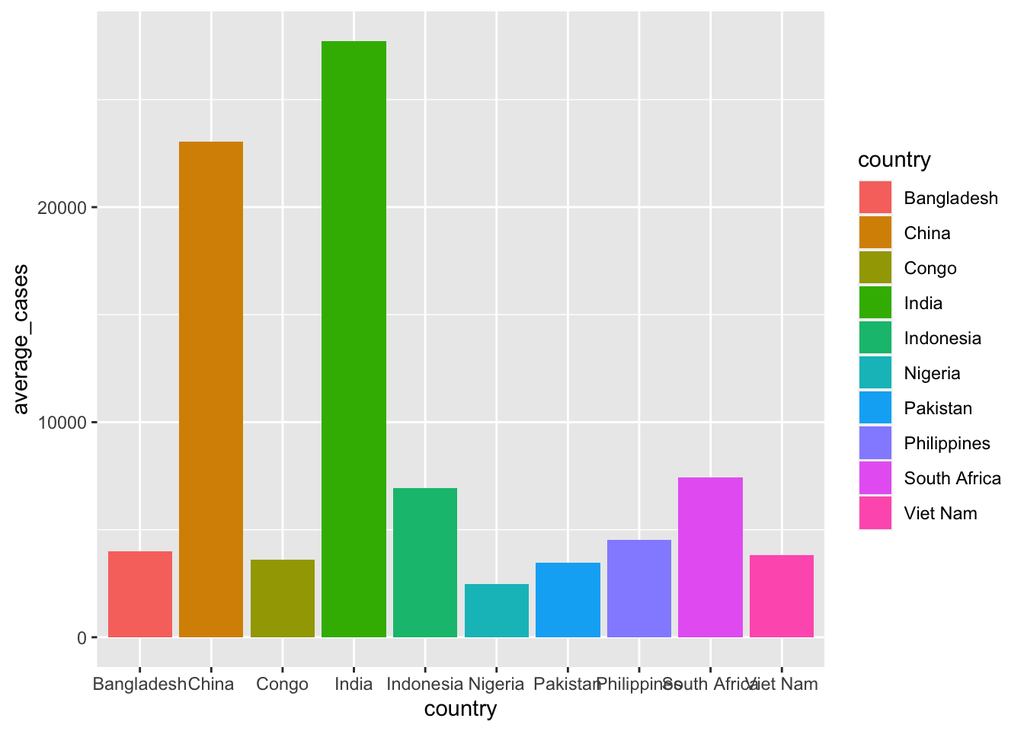

```r
# Shorten country name for cleaner plot
top_ten2 <- top_ten1 %>%
  mutate(country = str_replace(country,
                               "Democratic Republic of the Congo",
                               "Congo"
                               )
         )

ggplot(data = top_ten2) +
  geom_col(aes(x = country, y = average_cases, fill = country))
```

This confirms the results we found in the earlier section. Two countries, China and India, have significant average tuberculosis cases compared to the other top 10 countries. Lets see how the average cases vary in different years. We will use the `top_ten1` tibble to filter the original dataset `who` with the `semi_join` function.

```r
top_ten3 <- who %>%
  # limit the original dataset to top 10 countries
  semi_join(top_ten1, by = "country") %>%
  group_by(country, year) %>%
  # calculate average cases per year
  summarise(average_cases = round(mean(cases), 0)) %>%
  ungroup()
```

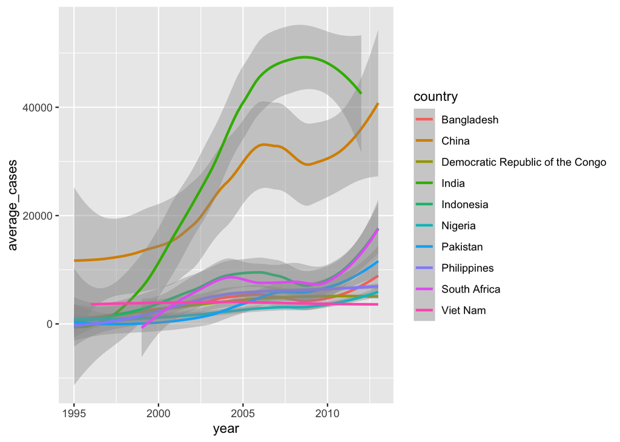

```r
ggplot(data = top_ten3) +
  geom_smooth(aes(x = year, y = average_cases, color = country))
```

From the plot above, we can see that there is clearly a rising trend in the average tuberculosis cases, most notably in the top 3 countries. For the final step, lets plot the average cases by age groups in the below plot.

```r
age_groups <- who %>%
  group_by(age) %>%
  summarise(average_cases = round(mean(cases), 0)) %>%
  arrange(average_cases)
```

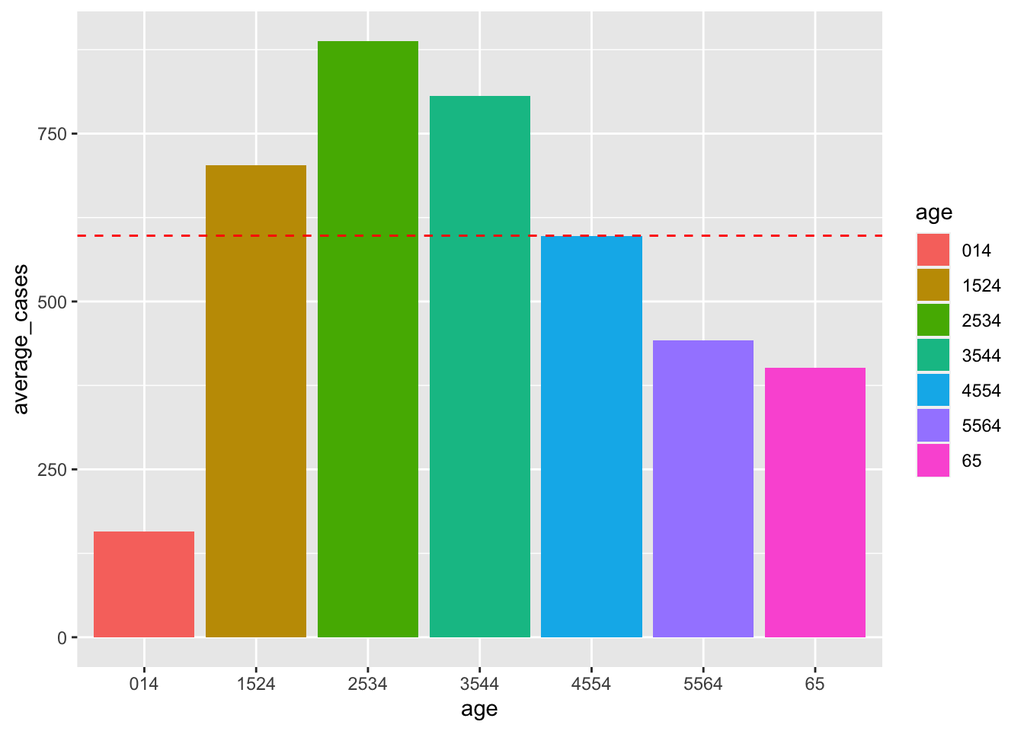

```r
ggplot(data = age_groups) +
  geom_col(aes(x = age, y = average_cases, fill = age)) +
  # add median line to the plot
  geom_abline(slope = 0,
              intercept = median(age_groups$average_cases),
              color = "red",
              lty = 2)
```

As we can see, the age groups from 15 to 44 are above the median line and the age groups 0-14 and 45-65 are below the median line. This indicates in some degree that tuberculosis is less common in the older age groups. We will confirm this relation in the next section of this case study.

# Modelling Data

We have now gained enough information about our data, so we can use modelling to find evidence about the relation of age and gender to the average tuberculosis cases. We will do this with simple linear regression which can be modelled with the `lm` function.

Our first model will be in the form of:

$$cases = \beta_0 + \beta_1age\_group + \epsilon$$

We start by creating a dummy variable for age groups forming two variables: “young” and “old”. We will exclude the youngest age group (0-14) as an outlier.

```r
model_data <- who %>%
  filter(age != "014") %>%
  mutate(age_group = ifelse(age == "1524" | age == "2543" | age == "3544",
         "young", "old"))
```

Then we run the linear regression.

```r
model1 <- lm(cases ~ age_group, data = model_data)
summary(model1)
```

```
##
## Call:
## lm(formula = cases ~ age_group, data = model_data)
##
## Residuals:
##    Min     1Q Median     3Q    Max
##   -755   -582   -568   -411 249296
##
## Coefficients:
##                Estimate Std. Error t value Pr(>|t|)
## (Intercept)      582.20      18.26  31.879  < 2e-16 ***
## age_groupyoung   172.50      31.62   5.456 4.89e-08 ***
## ---
## Signif. codes:  0 '***' 0.001 '**' 0.01 '*' 0.05 '.' 0.1 ' ' 1
##
## Residual standard error: 3806 on 65162 degrees of freedom
## Multiple R-squared:  0.0004566,  Adjusted R-squared:  0.0004413
## F-statistic: 29.77 on 1 and 65162 DF,  p-value: 4.888e-08
```

The variable age_group has a positive and statistically significant coefficient at the 5% level of significance. This confirms that the age groups have significant effect on the tuberculosis cases. Lets add the gender variable to our model. Now the model will be in the form of:

$$cases = \beta_0 + \beta_1age\_group + \beta_2sex + \epsilon$$

```r
model2 <- lm(cases ~ age_group + sex, data = model_data)
summary(model2)
```

```
##
## Call:
## lm(formula = cases ~ age_group + sex, data = model_data)
##
## Residuals:
##    Min     1Q Median     3Q    Max
##   -932   -739   -466   -339 249119
##
## Coefficients:
##                Estimate Std. Error t value Pr(>|t|)
## (Intercept)      404.57      23.57  17.166  < 2e-16 ***
## age_groupyoung   172.40      31.58   5.459 4.81e-08 ***
## sexm             354.58      29.78  11.905  < 2e-16 ***
## ---
## Signif. codes:  0 '***' 0.001 '**' 0.01 '*' 0.05 '.' 0.1 ' ' 1
##
## Residual standard error: 3801 on 65161 degrees of freedom
## Multiple R-squared:  0.002626,   Adjusted R-squared:  0.002595
## F-statistic: 85.78 on 2 and 65161 DF,  p-value: < 2.2e-16
```

The coefficients for the two variables are again positive and statistically significant, indicating that both variables have significant effect on tuberculosis cases.

This concludes our analysis this time. We cleaned a dataset and computed summarising values. Then we visualized the data and finally applied modelling to our data. Next time, we will visualize some recent covid-19 data. Don’t forget to check out my other [projects](https://eenaveis.github.io/)!